# Chapter 5 Dimensionality reduction

**Description about week 5**

```r
library(FactoMineR)
library(GGally)
library(tidyverse)
```

## 1. Overview of the data

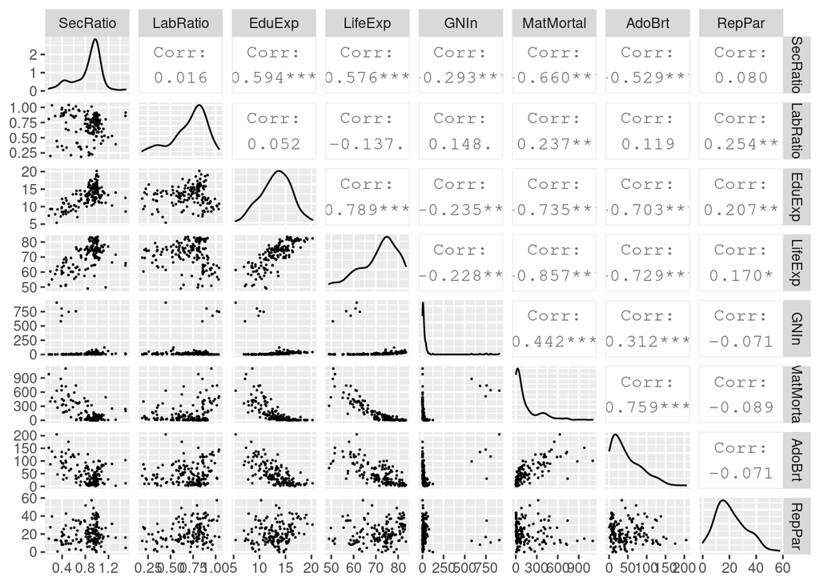

```r
# Read data
dat <- read.csv("data/human.csv", row.names = "X")

GGally::ggpairs(dat, lower = list(continuous = wrap("points", size=0.1)))
```

Some distributions are very skewed, resembling exponential or power-law distribution. Others look somewhat normal. Most correlations between the variables are notable, with some exeptions being LabRatio~SecRatio, EduExp~LabRatio and AdoBrt~RepPar.

## 2. Principal components analysis

Let’s do principal components analysis to the human data.

```r
res.pca <- princomp(dat)
summary(res.pca)
```

```
## Importance of components:
##                            Comp.1     Comp.2      Comp.3       Comp.4
## Standard deviation     226.103260 120.524383 26.31142349 11.415380196
## Proportion of Variance   0.768889   0.218474  0.01041211  0.001959886
## Cumulative Proportion    0.768889   0.987363  0.99777513  0.999735011
##                              Comp.5       Comp.6       Comp.7       Comp.8
## Standard deviation     3.8726938744 1.5996468715 1.918696e-01 1.593393e-01
## Proportion of Variance 0.0002255674 0.0000384856 5.536845e-07 3.818526e-07
## Cumulative Proportion  0.9999605789 0.9999990645 9.999996e-01 1.000000e+00
```

```r
res.pca$loadings
```

```
##
## Loadings:
##           Comp.1 Comp.2 Comp.3 Comp.4 Comp.5 Comp.6 Comp.7 Comp.8
## SecRatio                                             0.690  0.723
## LabRatio                                             0.722 -0.691
## EduExp                                 0.191  0.980
## LifeExp                                0.976 -0.194
## GNIn      -0.398  0.917
## MatMortal -0.907 -0.392  0.152
## AdoBrt    -0.134        -0.988
## RepPar                          0.996
##
##                Comp.1 Comp.2 Comp.3 Comp.4 Comp.5 Comp.6 Comp.7 Comp.8
## SS loadings     1.000  1.000  1.000  1.000  1.000  1.000  1.000  1.000
## Proportion Var  0.125  0.125  0.125  0.125  0.125  0.125  0.125  0.125
## Cumulative Var  0.125  0.250  0.375  0.500  0.625  0.750  0.875  1.000
```

The first component captures ~77% of the variability, and the second 22%. The rest are negligible. The biplot between 1st and 2nd PC is presented below.

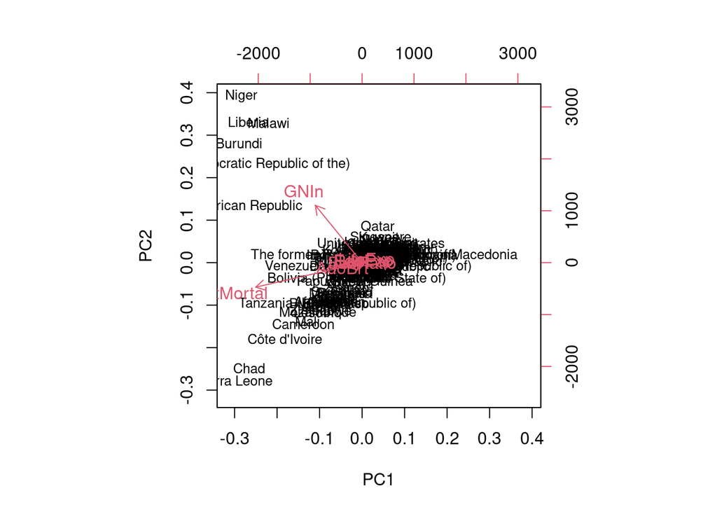

```r
biplot(res.pca, cex = c(0.8, 1), xlab="PC1", ylab = "PC2")
```

## 3. Standaridzed data

Next we do the same thing as above, but with standardized data

```r
# Standardize the data
dat_z <- scale(dat)

# Principal component analysiks
res.pca2 <- princomp(dat_z)
summary(res.pca2)
```

```
## Importance of components:
##                          Comp.1   Comp.2    Comp.3    Comp.4     Comp.5
## Standard deviation     1.990068 1.145425 0.9406608 0.8524938 0.68677519
## Proportion of Variance 0.498240 0.165058 0.1113189 0.0914293 0.05933789
## Cumulative Proportion  0.498240 0.663298 0.7746169 0.8660462 0.92538411
##                            Comp.6     Comp.7     Comp.8
## Standard deviation     0.53072986 0.46343833 0.31088801
## Proportion of Variance 0.03543643 0.02702009 0.01215936
## Cumulative Proportion  0.96082054 0.98784064 1.00000000
```

```r
res.pca2$loadings
```

```
##
## Loadings:
##           Comp.1 Comp.2 Comp.3 Comp.4 Comp.5 Comp.6 Comp.7 Comp.8
## SecRatio   0.377                0.377  0.804  0.199         0.131
## LabRatio          0.717         0.582 -0.267        -0.242
## EduExp     0.433  0.180  0.186        -0.182 -0.380  0.746 -0.105
## LifeExp    0.452         0.193 -0.206 -0.103 -0.365 -0.444  0.612
## GNIn      -0.225  0.194  0.847 -0.343  0.186  0.112        -0.163
## MatMortal -0.470  0.121                       0.156  0.422  0.748
## AdoBrt    -0.427        -0.121         0.410 -0.790
## RepPar            0.628 -0.428 -0.598  0.190  0.141
##
##                Comp.1 Comp.2 Comp.3 Comp.4 Comp.5 Comp.6 Comp.7 Comp.8
## SS loadings     1.000  1.000  1.000  1.000  1.000  1.000  1.000  1.000
## Proportion Var  0.125  0.125  0.125  0.125  0.125  0.125  0.125  0.125
## Cumulative Var  0.125  0.250  0.375  0.500  0.625  0.750  0.875  1.000
```

And the corresponding biplot:

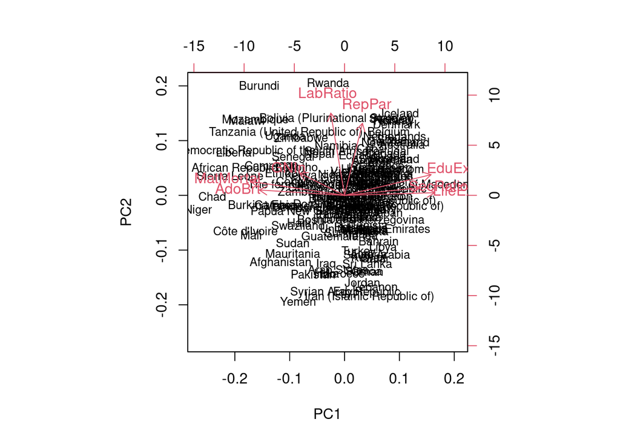

```r
biplot(res.pca2, cex = c(0.8, 1), xlab="PC1", ylab = "PC2")
```

## 4. Interpretation

In the first analysis (without standardization) the first component explains majority of variance. However, only few variables load on this component, and maternal mortality loads on the component very strongly. GNI variable loads on the second component very strongly. It almost seems that each component roughly corresponds to each variable in the data

In the latter results, both variance explained and variable loadings is spread bit more evenly across components. I guess this has something to do with the fact that maternal mortality had the greatest variance in the original data, and thus the corresponding component explains the most variance simply because of that. Now when variables are standardized, unequal variances do not confound the analysis anymore.

## 5. Multiple Correspondence Analysis

Couldn’t get this to work.